# TidyVerse CREATE

Shane Hylton

11/15/2021

## Overview

Tidyverse is a versatile tool for data science and I will be using a [fivethirtyeight](https://projects.fivethirtyeight.com/2021-nfl-predictions/) dataset to dive into tidyverse. This comprehensive package offers a wide array of dataframe tools, as well as tools to manipulate other forms of data. In short, tidyverse is the master key for data manipulation.

### Loading all Tidyverse packages

```r
library(tidyverse)
```

```r
library(dplyr)
library(purrr)
library(ggplot2)
library(readr)
library(stringr)
library(tidyr)
library(tibble)
library(forcats)
```

By loading library(tidyverse), all of the packages are also loaded, so it was just an extra step to intentionally list out all eight packages. It is pretty clear that someone on the naming team at tidyverse loves cats.

## Loading the Data

```r
link <- 'https://raw.githubusercontent.com/st3vejobs/tidyverse-CREATE/main/nfl_elo_latest.csv'
raw <- read.csv(url(link), na.strings = "")

raw <- subset(raw, select = -c(playoff))

nfl <- na.omit(raw)
```

### filter( )

If I only wanted to see Elo changes over time in the month of October, I can use filter( ) from the dplyr package in tidyverse.

```r
oct <- nfl %>%
  filter(date >= "2021-10-01", date < "2021-11-01")

head(oct)
```

```
##         date season neutral team1 team2 elo1_pre elo2_pre elo_prob1 elo_prob2
## 1 2021-10-03   2021       0   CHI   DET 1467.762 1356.949 0.7334239 0.2665761
## 2 2021-10-03   2021       0   PHI    KC 1429.401 1610.832 0.3384448 0.6615552
## 3 2021-10-03   2021       0   NYJ   TEN 1332.623 1544.821 0.2999907 0.7000093
## 4 2021-10-03   2021       0   MIA   IND 1493.752 1498.930 0.5852496 0.4147504
## 5 2021-10-03   2021       0   ATL   WSH 1443.767 1439.248 0.5987316 0.4012684
## 6 2021-10-03   2021       0   BUF   HOU 1648.028 1405.664 0.8543736 0.1456264
##   elo1_post elo2_post qbelo1_pre qbelo2_pre             qb1             qb2
## 1  1479.601  1345.110   1448.692   1338.897   Justin Fields      Jared Goff
## 2  1412.912  1627.322   1438.790   1609.937     Jalen Hurts Patrick Mahomes
## 3  1353.423  1524.021   1347.976   1527.587     Zach Wilson  Ryan Tannehill
## 4  1464.900  1527.782   1490.794   1472.099 Jacoby Brissett    Carson Wentz
## 5  1423.865  1459.149   1427.519   1469.368       Matt Ryan Taylor Heinicke
## 6  1657.518  1396.174   1618.630   1373.595      Josh Allen     Davis Mills
##   qb1_value_pre qb2_value_pre    qb1_adj     qb2_adj qbelo_prob1 qbelo_prob2
```

[output cut: 20 more lines]

### arrange( )

Now, let’s say I wanted to go back to the nfl dataframe and sort it by the importance of the game.

```r
nfl_important <- arrange(nfl, desc(importance))

paste("The most important game so far this season was on November 14 where the Chiefs defeated the Raiders. ")
```

```
## [1] "The most important game so far this season was on November 14 where the Chiefs defeated the Raiders. "
```

```r
nfl_important[1, ]
```

```
##         date season neutral team1 team2 elo1_pre elo2_pre elo_prob1 elo_prob2
## 1 2021-11-14   2021       0   OAK    KC 1500.814 1609.987 0.4367708 0.5632292
##   elo1_post elo2_post qbelo1_pre qbelo2_pre        qb1             qb2
## 1  1472.279  1638.522   1487.522   1588.911 Derek Carr Patrick Mahomes
##   qb1_value_pre qb2_value_pre  qb1_adj   qb2_adj qbelo_prob1 qbelo_prob2
## 1      192.6431      209.2709 3.533611 -13.41658   0.4643178   0.5356822
##   qb1_game_value qb2_game_value qb1_value_post qb2_value_post qbelo1_post
## 1       178.9716       492.7609        191.276       237.6199    1456.924
##   qbelo2_post score1 score2 quality importance total_rating
## 1     1619.51     14     41      65         98           82
```

### Rename ( )

Two of the columns have names that are not arranged properly and they may be confusing. I will rename them to make them easier to understand. They are the quarterback-adjusted win probabilities for each team in a particular game.

```r
nfl_important <- nfl_important %>% rename(qb1_adjusted_elo_prob = qbelo_prob1, qb2_adjusted_elo_prob = qbelo_prob2)
```

### Select ( )

Select is another subsetting tool that goes a bit deeper. I will create a subset of all Chicago Bears games and then I will select a few key columns.

```r
bears <- subset(nfl_important, team1 == "CHI" | team2 == "CHI")
bearst1 <- subset(bears, team1 == "CHI")
bearst2 <- subset(bears, team2 == "CHI")

bearsqb_elo_1 <- bearst1 %>% select(team1,elo_prob1,qb1,qb1_adjusted_elo_prob,importance)
bearsqb_elo_1 <- bearsqb_elo_1 %>% rename(team = team1, elo_prob = elo_prob1, qb = qb1, qb_elo_prob = qb1_adjusted_elo_prob)
bearsqb_elo_2 <- bearst2 %>% select(team2,elo_prob2,qb2,qb2_adjusted_elo_prob,importance)
bearsqb_elo_2 <- bearsqb_elo_2 %>% rename(team = team2, elo_prob = elo_prob2, qb = qb2, qb_elo_prob = qb2_adjusted_elo_prob)
bearsqb_elo <- rbind(bearsqb_elo_1,bearsqb_elo_2)
bearsqb_elo
```

```
##     team  elo_prob            qb qb_elo_prob importance
## 24   CHI 0.4232868 Justin Fields   0.3971045         80
## 81   CHI 0.6226012 Justin Fields   0.5132856         51
## 84   CHI 0.6619565   Andy Dalton   0.5729006         49
## 133  CHI 0.7334239 Justin Fields   0.6645030         16
## 75   CHI 0.3080676   Andy Dalton   0.2659959         54
## 90   CHI 0.3560446 Justin Fields   0.3041971         47
## 91   CHI 0.3400144 Justin Fields   0.2682454         46
## 95   CHI 0.3035732 Justin Fields   0.3072571         38
## 115  CHI 0.1954160 Justin Fields   0.1522307         21
```

### Relocate ( )

With the new dataframe, I would like to reorder the columns so that it is easier to view. Team may be unnecessary, but I will move it to the end just in case. I would like to list the QB first so it is easier to analyze the value of each quarterback.

```r
bearsqb_elo <- bearsqb_elo %>% relocate(qb, team)
bearsqb_elo <- bearsqb_elo %>% relocate(team, .after = importance)
```

### Add_Column ( ), stringr commands, group_by ( )

Now, I will perform some additional manipulation on the dataframe.

```r
qb_impact <- bearsqb_elo$qb_elo_prob - bearsqb_elo$elo_prob

names <- unlist(bearsqb_elo$qb)
first <- names[seq(1,length(names),by = 1)]

first <- str_extract(names, '[A-Z].{1,30}')
first <- c(str_trim(str_extract(names, '.+\\s{1,}')))
initials <- str_extract_all(first, '(^[A-Z])|(\\s)([A-Z])')
first_initial <- str_extract(first, '^[A-Z]')

bearsqb_elo <- bearsqb_elo %>% add_column(qb_impact)
bearsqb_elo <- bearsqb_elo %>% relocate(qb_impact, .before = importance)
bearsqb_elo <- bearsqb_elo %>% add_column(first_initial)
bearsqb_elo <- bearsqb_elo %>% relocate(first_initial, .after = qb)
bearsqb_elo$qb <- as.factor(bearsqb_elo$qb)

bearsqb_elo <- bearsqb_elo %>% group_by(qb) %>% arrange(qb)
#Note: arrange must be used with group_by to rearrange rows. group_by does not affect the layout of rows.

bearsqb_elo
```

```
## # A tibble: 9 × 7
## # Groups:   qb [2]
##   qb            first_initial elo_prob qb_elo_prob qb_impact importance team
##   <fct>         <chr>            <dbl>       <dbl>     <dbl>      <int> <chr>
## 1 Andy Dalton   A                0.662       0.573  -0.0891          49 CHI
## 2 Andy Dalton   A                0.308       0.266  -0.0421          54 CHI
## 3 Justin Fields J                0.423       0.397  -0.0262          80 CHI
## 4 Justin Fields J                0.623       0.513  -0.109           51 CHI
## 5 Justin Fields J                0.733       0.665  -0.0689          16 CHI
## 6 Justin Fields J                0.356       0.304  -0.0518          47 CHI
## 7 Justin Fields J                0.340       0.268  -0.0718          46 CHI
## 8 Justin Fields J                0.304       0.307   0.00368         38 CHI
## 9 Justin Fields J                0.195       0.152  -0.0432          21 CHI
```

### Mutate ( )

Mutate takes a function found in base R and makes it even better. I will perform a couple of example mutations below. I performed the base R version of this function above with qb_impact.

```r
bearsqb_elo <- bearsqb_elo %>%
  mutate(mean_elo_prob = (elo_prob + qb_elo_prob)/2)
```

As one can see, this provides a more streamlined approach to a similar calculation.

### ggplot ( )

Here, I will use a new subset for the Chicago Bears, and this time I will plot Elo over time using ggplot2.

```r
bears <- subset(nfl_important, team1 == "CHI" | team2 == "CHI")
bearst1 <- subset(bears, team1 == "CHI")
bearst2 <- subset(bears, team2 == "CHI")

bearsqb_elo_1 <- bearst1 %>% select(date, team1, elo1_pre, elo1_post, elo_prob1, qb1, qb1_adjusted_elo_prob, importance)
bearsqb_elo_1 <- bearsqb_elo_1 %>% rename(team = team1, elo_pre = elo1_pre, elo_post = elo1_post, elo_prob = elo_prob1, qb = qb1, qb_elo_prob = qb1_adjusted_elo_prob)
bearsqb_elo_2 <- bearst2 %>% select(date, team2, elo2_pre, elo2_post, elo_prob2, qb2, qb2_adjusted_elo_prob, importance)
bearsqb_elo_2 <- bearsqb_elo_2 %>% rename(team = team2, elo_pre = elo2_pre, elo_post = elo2_post, elo_prob = elo_prob2, qb = qb2, qb_elo_prob = qb2_adjusted_elo_prob)
bears <- rbind(bearsqb_elo_1,bearsqb_elo_2)
bears
```

```
##           date team  elo_pre elo_post  elo_prob            qb qb_elo_prob
## 24  2021-10-17  CHI 1513.175 1493.359 0.4232868 Justin Fields   0.3971045
## 81  2021-10-31  CHI 1480.761 1448.546 0.6226012 Justin Fields   0.5132856
## 84  2021-09-19  CHI 1478.535 1487.436 0.6619565   Andy Dalton   0.5729006
## 133 2021-10-03  CHI 1467.762 1479.601 0.7334239 Justin Fields   0.6645030
## 75  2021-09-12  CHI 1496.167 1478.535 0.3080676   Andy Dalton   0.2659959
## 90  2021-10-10  CHI 1479.601 1513.175 0.3560446 Justin Fields   0.3041971
## 91  2021-09-26  CHI 1487.436 1467.762 0.3400144 Justin Fields   0.2682454
## 95  2021-11-08  CHI 1448.546 1442.286 0.3035732 Justin Fields   0.3072571
## 115 2021-10-24  CHI 1493.359 1480.761 0.1954160 Justin Fields   0.1522307
##     importance
## 24          80
## 81          51
## 84          49
## 133         16
## 75          54
## 90          47
## 91          46
## 95          38
## 115         21
```

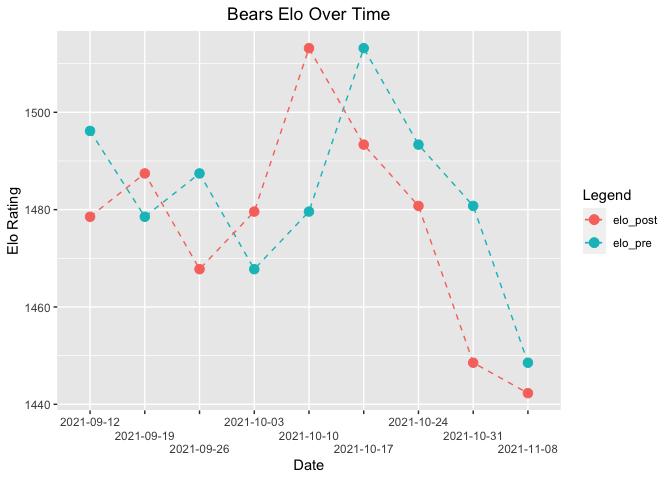

```r
ggplot(bears)+
  geom_point(aes(x = date, y = elo_pre, color = "elo_pre"), size=3)+
  geom_point(aes(x = date, y = elo_post, color = "elo_post"), size=3)+
  ggtitle('Bears Elo Over Time')+
  labs(
    x = 'Date',
    y = 'Elo Rating',
    color = 'Legend')+
  geom_line(aes(x = date, y = elo_pre, group = 1, color = "elo_pre"), linetype = "dashed")+
  geom_line(aes(x = date, y = elo_post, group = 1, color = "elo_post"), linetype = "dashed")+
  theme(plot.title = element_text(hjust = 0.5), )+
  scale_x_discrete(guide = guide_axis(n.dodge = 3))
```

It is clear that tidyverse is one of the most valuable tools for data manipulation and analysis. String manipulation, dataframe tidying, dataframe manipulation, and plotting are all made so much better by tidyverse.

### Data Source

https://projects.fivethirtyeight.com/2021-nfl-predictions/

https://www.tidyverse.org